# Red Wine Exploration

David Oguara

July 2018

## Introduction

This report explores the attributes of red wines, and attempts to link these attributes with quality ratings by wine experts. By the end of this report, we should have gained some insight into the characteristics of ‘good’ red wine, as rated by experts.

## Loading the data set

The red wines data set contains nearly 1600 observations and 12 attributes, including density, alcohol content, and acidity. Each observation has a wine expert’s rating, designated by the column quality.

Of course, in the real world wine quality is very subjective. Given, however, that quality rating in the dataset is published by experts, its consistency is likely to be superior to ratings by the general public.

```
##  [1] "X"                    "fixed.acidity"        "volatile.acidity"
##  [4] "citric.acid"          "residual.sugar"       "chlorides"
##  [7] "free.sulfur.dioxide"  "total.sulfur.dioxide" "density"
## [10] "pH"                   "sulphates"            "alcohol"
## [13] "quality"
```

```
## 'data.frame':    1599 obs. of  13 variables:
##  $ X                   : int  1 2 3 4 5 6 7 8 9 10 ...
##  $ fixed.acidity       : num  7.4 7.8 7.8 11.2 7.4 7.4 7.9 7.3 7.8 7.5 ...
##  $ volatile.acidity    : num  0.7 0.88 0.76 0.28 0.7 0.66 0.6 0.65 0.58 0.5 ...
##  $ citric.acid         : num  0 0 0.04 0.56 0 0 0.06 0 0.02 0.36 ...
##  $ residual.sugar      : num  1.9 2.6 2.3 1.9 1.9 1.8 1.6 1.2 2 6.1 ...
##  $ chlorides           : num  0.076 0.098 0.092 0.075 0.076 0.075 0.069 0.065 0.073 0.071 ...
##  $ free.sulfur.dioxide : num  11 25 15 17 11 13 15 15 9 17 ...
##  $ total.sulfur.dioxide: num  34 67 54 60 34 40 59 21 18 102 ...
##  $ density             : num  0.998 0.997 0.997 0.998 0.998 ...
##  $ pH                  : num  3.51 3.2 3.26 3.16 3.51 3.51 3.3 3.39 3.36 3.35 ...
##  $ sulphates           : num  0.56 0.68 0.65 0.58 0.56 0.56 0.46 0.47 0.57 0.8 ...
##  $ alcohol             : num  9.4 9.8 9.8 9.8 9.4 9.4 9.4 10 9.5 10.5 ...
##  $ quality             : int  5 5 5 6 5 5 5 7 7 5 ...
```

## Univariate Plots Section

### Quality Ratings

What is the distribution of quality ratings in our dataset?

```
##    Min. 1st Qu.  Median    Mean 3rd Qu.    Max.
##   3.000   5.000   6.000   5.636   6.000   8.000
```

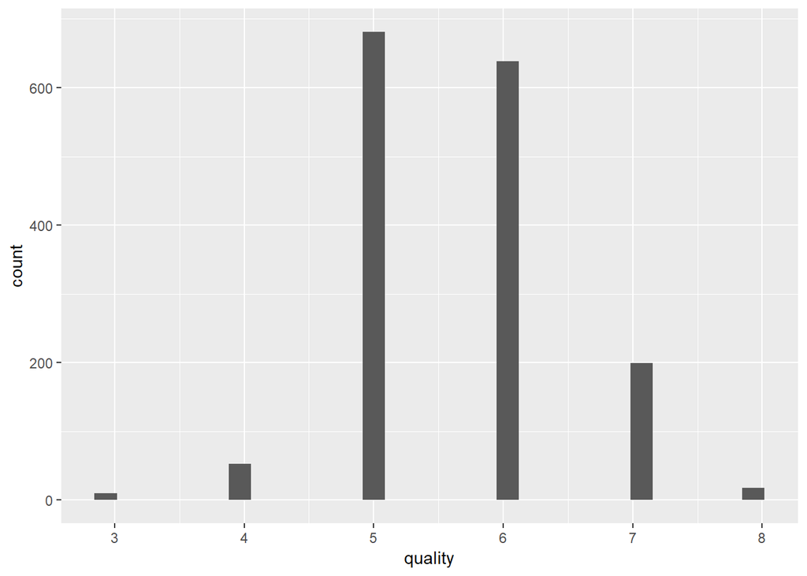

A very small number of observations fall to each end of the distribution. Very few wines are rated lowest (quality rating 3) and very few wines are rated highest (quality rating of 8).

### Acidity

Acids are among the most important components of red wine. Acid concentration, in milligrams per liter of wine, is typically higher than most other compounds in wine. Additional information can be found here: (http://waterhouse.ucdavis.edu/whats-in-wine/red-wine-composition)

Acids are what give wine its sour taste. They conteract and balance the sweetness that arises from sugars, natural or otherwise, present in grapes from which wine is made. Fixed acids typically originate in the grapes, while volatile acids are mostly produced by microbial and yeast action during fermentation.

It will therefore be quite instructive to see what the acidity levels are of wines in our data.

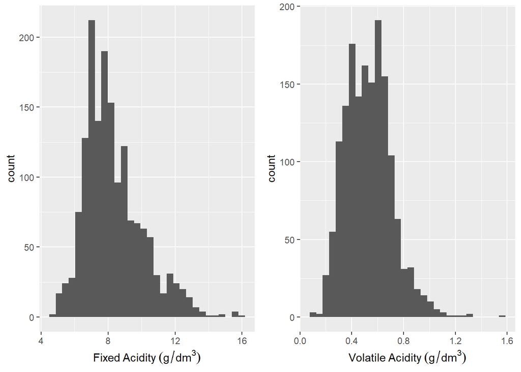

Fixed acidity and volatile acidity histograms above show that majority of wines seem to have moderate acidity.

```
##    Min. 1st Qu.  Median    Mean 3rd Qu.    Max.
##    4.60    7.10    7.90    8.32    9.20   15.90
```

```
##    Min. 1st Qu.  Median    Mean 3rd Qu.    Max.
##  0.1200  0.3900  0.5200  0.5278  0.6400  1.5800
```

Units or measurement are same for both acid types. There is much more fixed acids in wine than volatile.

Fixed acids range from 4.6 to 15.9, with the mean of 8.3.

Volatile acids range from 0.12 to 1.58, with a mean of 0.52.

Both distributions appear to be close to normal, with a few outliers.

### Residual sugar

To make wine, yeast and bacteria are introduced to grapes, which then proceed to feast on the natural sugars present in the grapes in what is called the fermentation process. The sugar left over, not consumed by bacteria and yeast, are referred to as residual sugar.

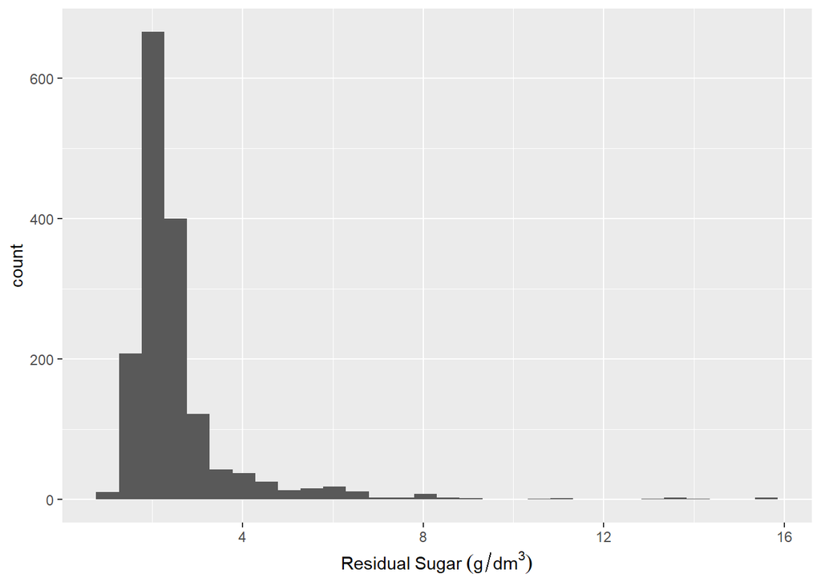

```
##    Min. 1st Qu.  Median    Mean 3rd Qu.    Max.
##   0.900   1.900   2.200   2.539   2.600  15.500
```

Values for residual sugar have huge dispersion, ranging from 1 to 16. The bulk of the values seem to lie between 1 and 5, with many outliers. I wonder what the plots will look like if we apply limits to narrow the range, say from 1 to 5. I would also like to see what log-transformed residual sugar looks like, side by side. Lets plot three graphs.

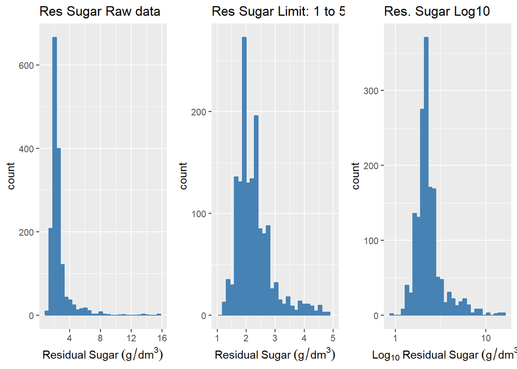

Certainly, using either the range-limited data or the log-transformed data will be preferable to using the raw data. I think I will use the log-transform for further analysis, since I preserve all records thusly.

### Alcohol

Alcohol is produced by yeast as they metabolise the natural sugars in grape. Wine makers have developed finely calibrated methods to stop or inhibit this metabolism in order to actualise the desired level of alcohol content. Let us see how alcohol content, given as a percentage of volume, is distributed in our data set.

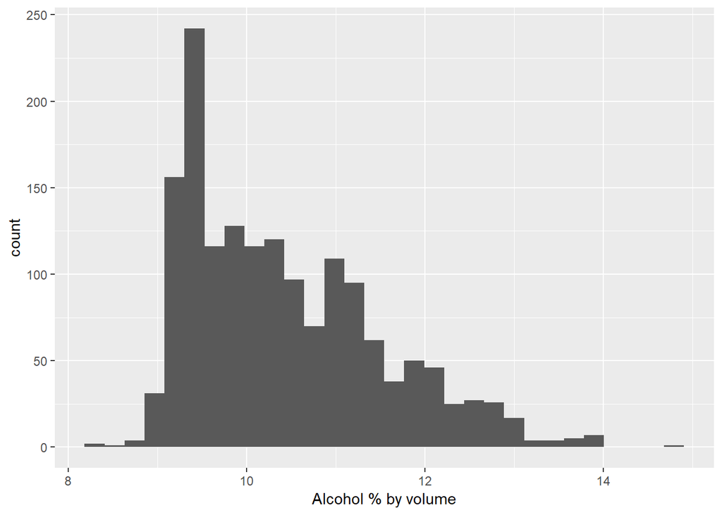

```
##    Min. 1st Qu.  Median    Mean 3rd Qu.    Max.
##    8.40    9.50   10.20   10.42   11.10   14.90
```

50% of observations in the dataset have alcohol content ranging from 9.5% to 11.1%. Lowest is 8.4% and highest is 14.9%. This pretty much matches what we observe with wine bottles in the wild, or rather, in shopping aisles.

### Sulfur dioxide

Alcohol in wine is produced as metabolic waste when yeast microbes digest grape sugars. Sulphur dioxide is added to the mixture at different stages to stop or otherwise inhibit this microbial action. Furthermore, while suphur dioxide is typically odorless and tasteless in low quantities, it can be detected when present in higher concentrations, manifesting in the nose and taste of wine.

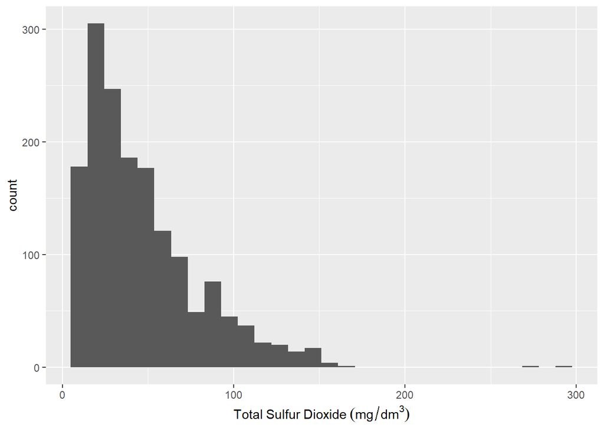

Total sulfur dioxide is highly skewed. Let’s apply a log transformation

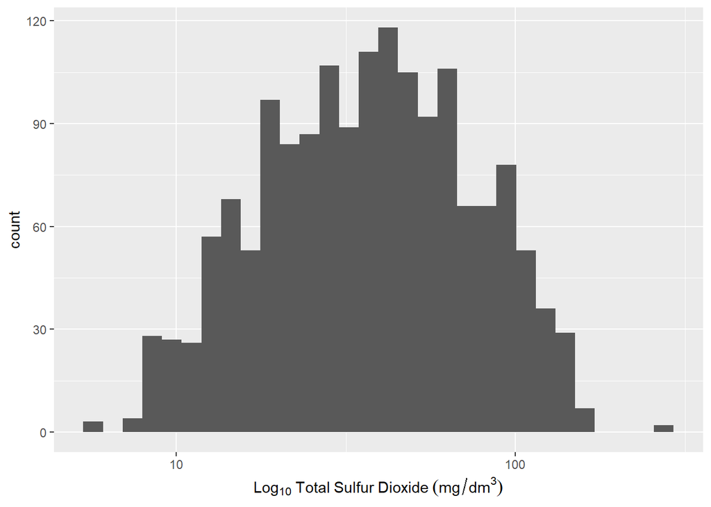

Applying log transformation does help minimise the skewedness of the distribution. We will therefore use log transformed total sulphur dioxide for subsequent analysis.

### Sulphates

In our dataset, sulphates are shown in a seperate column from total sulfur dioxide and free sulfur dioxide. These three are all related. Sulphates, or potassium sulphate, is added to wine and some of it gets converted to sulphur dioxide. Both compounds act to limit microbial action, thereby stopping or slowing the fermentation process and helping preserve the properties of the wine mixture.

Seeing we have reviewed the range spread of sulfur dioxide, let us do the same with potassium sulphate.

First, we look at the range of values in a summary.

```
##    Min. 1st Qu.  Median    Mean 3rd Qu.    Max.
##  0.3300  0.5500  0.6200  0.6581  0.7300  2.0000
```

Values range from 0.33 to 2. The table suggests the data will be heavily skewed to the right.

Let us look at a histogram of these values. We will also plot a log-transformed histogram side by side for comparison.

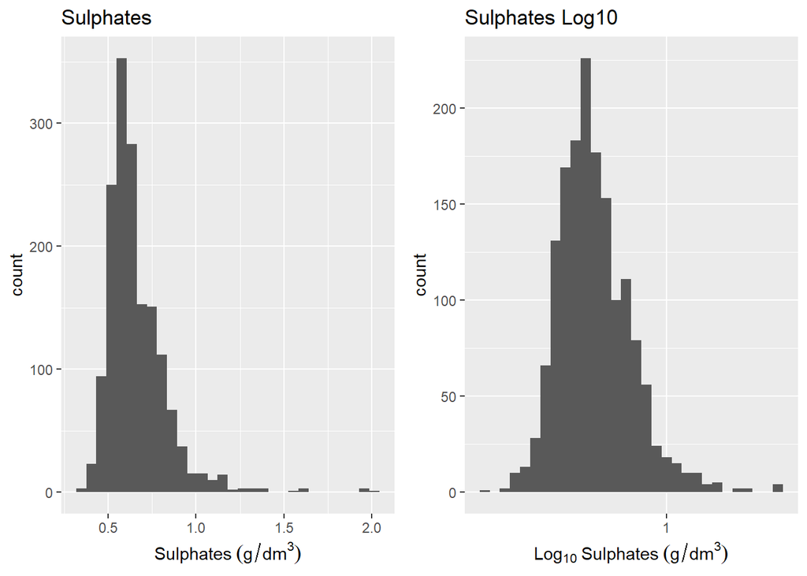

As expected, the values are skewed to the right. Using log10 transformation, we can restore normality to the distribution.

### Citric acid

Wikipedia says of citric acid:

> It is used less frequently than tartaric and malic due to the aggressive citric flavors it can add to the wine. When citric acid is added, it is always done after primary alcohol fermentation has been completed due to the tendency of yeast to convert citric into acetic acid. https://en.wikipedia.org/wiki/Acids_in_wine

I’m curious about this one. Do all wines have citric acid? If not, what’s the proportion of wines that contain it versus wines that do not?

```
## [1] "Proportion of wines with citric acid: 91.7%"
```

That’s quite a high number: nearly 92% of wines have citric acid. Let’s see a summary of values, and plot a histogram.

```
##    Min. 1st Qu.  Median    Mean 3rd Qu.    Max.
##   0.000   0.090   0.260   0.271   0.420   1.000
```

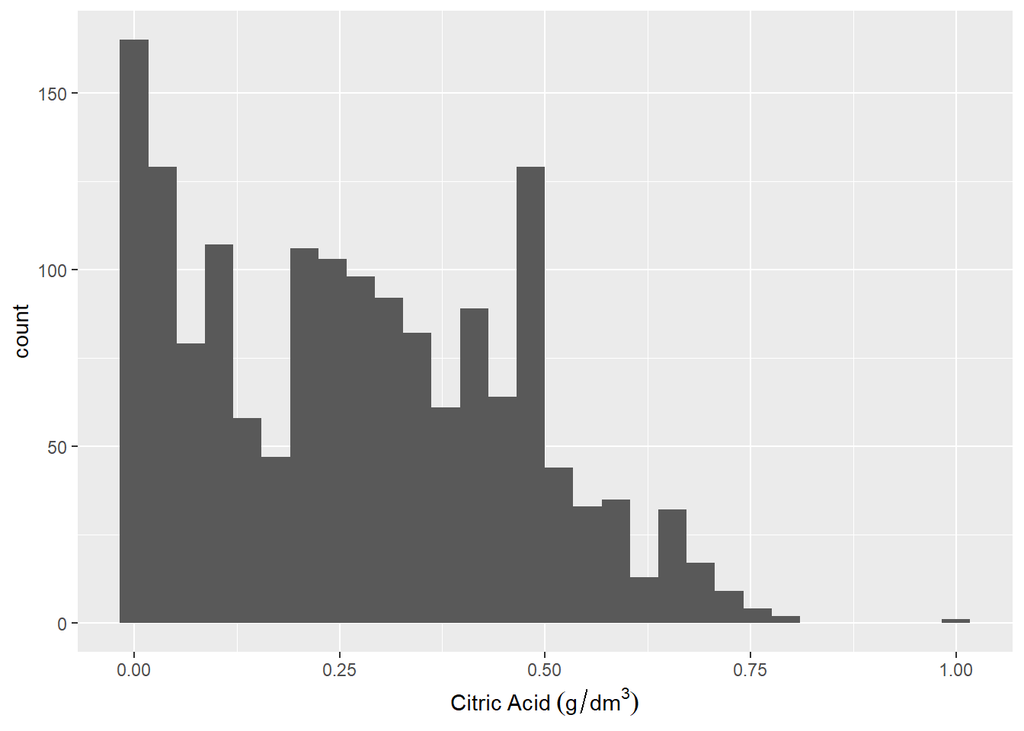

Will a log transform help with the skew observed above? Let us find out.

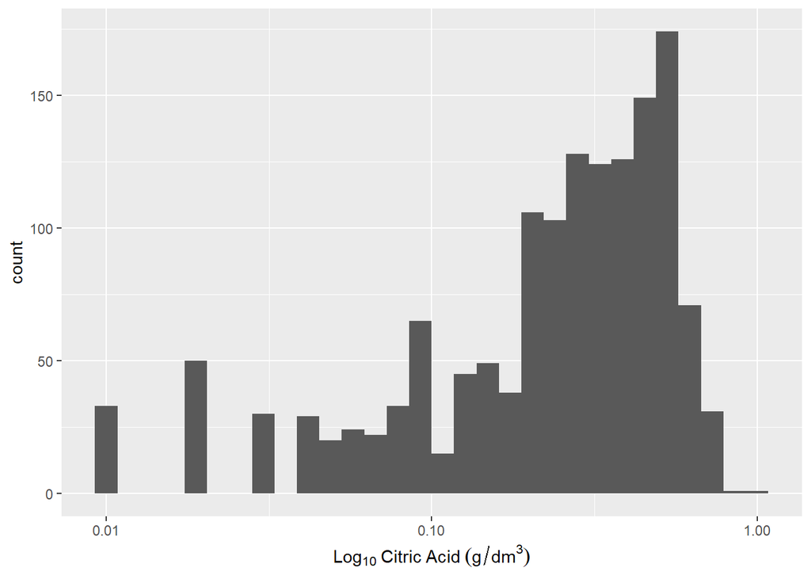

Log-transformation does not improve the data in terms of skewedness. We will therefore use the non-transformed raw data.

### Density

In our data set, density is given as grams per cubic centimetre. Density depends on alcohol and sugar content. Let’s see a summary table.

```
##    Min. 1st Qu.  Median    Mean 3rd Qu.    Max.
##  0.9901  0.9956  0.9968  0.9967  0.9978  1.0037
```

There’s only a very small spread in the data, from 0.99 to 1. And average density is 0.9967. Let’s plot a histogram

[figure not shown]

Wow, density values appear to be almost perfectly normal. Out of curiosity, I want to see a qqplot.

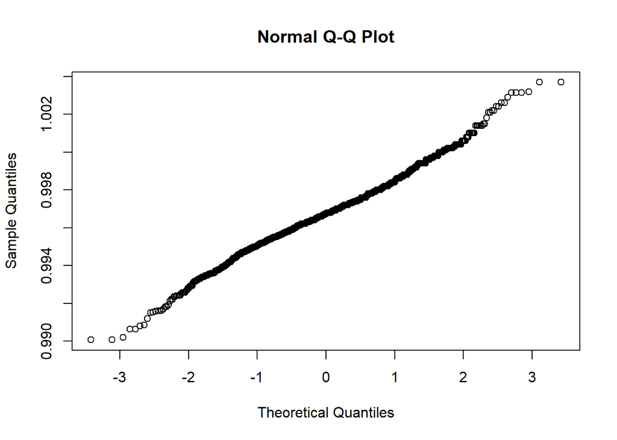

## Univariate Analysis

### Structure of the Dataset

Red wines dataset has nearly 1600 observations and 12 attributes. These are: fixed acidity, volatile acidity, citric acid, residual sugar, chlorides, free sulfur dioxide, total sulfur dioxide, density, pH, sulphates, alcohol and quality. Most of these attributes’ values are expressed in grams per cubic decimetre. Exceptions are density, alcohol and quality, which do not measure a compound but rather measure an overall attribute of the wine mixture.

### Featue of Interest

The main feature of interest is wine quality. Of the other given attributes, we are keen to understand whether any of these could serve as reliable predictors of wine quality.

## Bivariate Plots Section

### Acdity and Quality

Let us now see how wine quality relates to acidity. We will use scatter plots to find correlation.

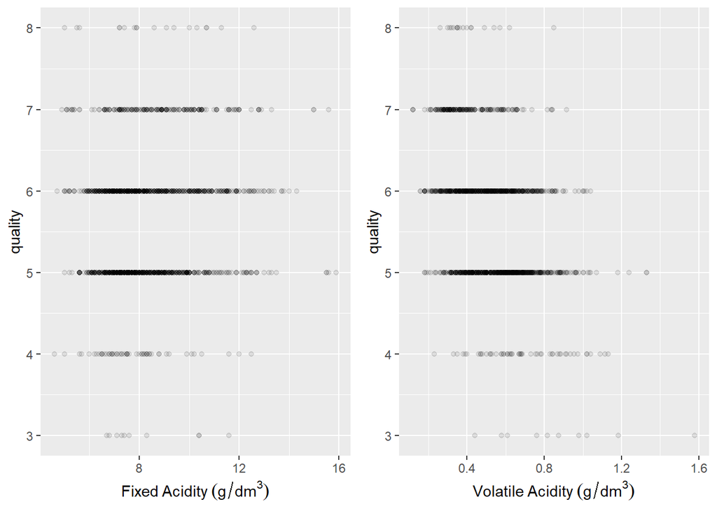

The above scatter plots tell a curious story. I observe that levels of fixed acidity in low quality and very high quality wines (3, 4, and 8) are barely distinguishable. Furthermore, highest levels of fixed acidity are associated with medium quality wines, in addition to a few wines with a quality of 7. Nevertheless, the bulk of the distribution seems to indicate wine fixed acidity does not predict wine quality.

With volatile acidity however, picture is slightly different. Highest quality wines appear likely to have lower levels of volatile acids.

I will run a couple quick correlation tests to confirm this.

```
##
##  Pearson's product-moment correlation
##
## data:  wines$fixed.acidity and wines$quality
## t = 4.996, df = 1597, p-value = 6.496e-07
## alternative hypothesis: true correlation is not equal to 0
## 95 percent confidence interval:
##  0.07548957 0.17202667
## sample estimates:
##       cor
## 0.1240516
```

```
##
##  Pearson's product-moment correlation
##
## data:  wines$volatile.acidity and wines$quality
## t = -16.954, df = 1597, p-value < 2.2e-16
## alternative hypothesis: true correlation is not equal to 0
## 95 percent confidence interval:
##  -0.4313210 -0.3482032
## sample estimates:
##        cor
## -0.3905578
```

So for fixed acids, coefficient of 0.12 suggests that fixed acidity does not correlate to quality. For volatile acidity however, there appears to be a moderate negative correlation of acidity levels to quality.

In reality, volatile acids account for a much smaller proportion of the red wine composition. It is therefore unlikely that volatile acids are by themselves driving this correlation. It is much more likely we are seeing a non-causative co-incidence.

Before moving on from acidity, I’m curious to see what the average acidity is per quality level of wine.

One way I can see this view is in a box plot, as below.

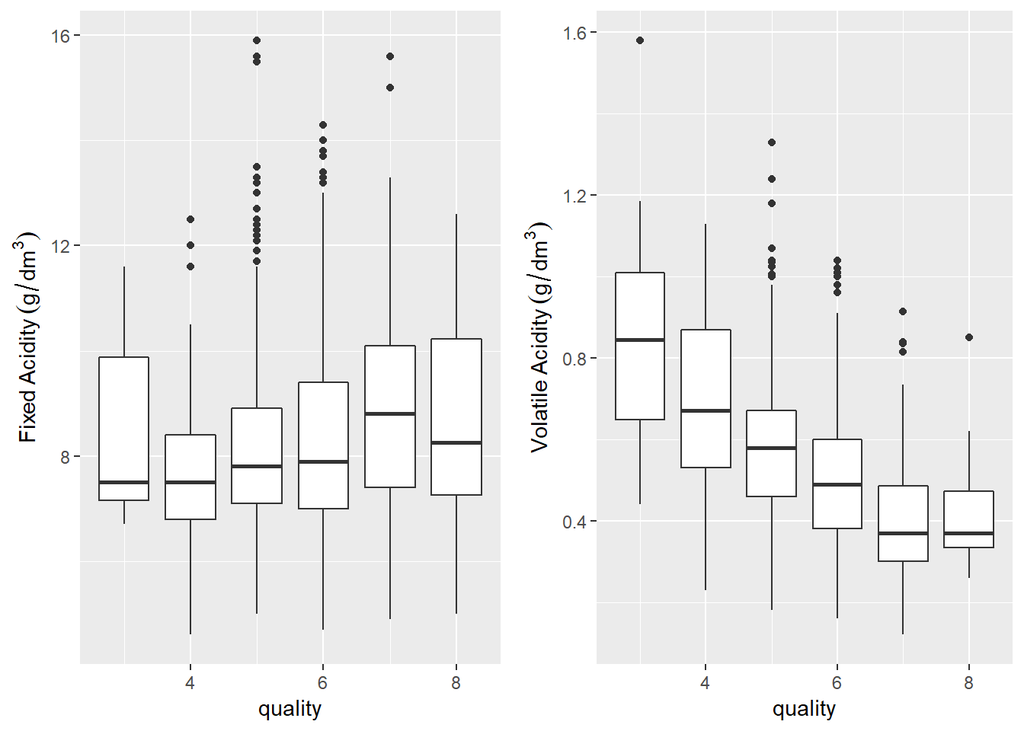

Average fixed acidity does not vary much across the quality levels. Wines of different quality levels will have very similar fixed acidity levels. This is supported by our weak correlation coefficient above. There are some interesting outliers however in the mid-range of quality, not surprising given the high number of wine observations that fall into this segment.

For volatile acids however, our plot seems to indicate an inverse relationship between average volatile acidity and wine quality. This agrees with observed moderate negative correlation coefficient. As observed earlier however, volatile acids are a minor component of red wines and it’s unlikely they are a causative factor here.

An alternative way to get a sense of average acidity across quality levels will be to group by quality and summarise acidity, that is, mean, median etc.

Indeed, this view will be useful across all the wine attributes. I will therefore now create a summary dataframe grouped by wine quality, and from which I will calculate mean, median, min, max and count values for each wine attribute.

```
## # A tibble: 6 x 46
##   quality mean_fixed.acid~ median_fixed.ac~ min_fixed.acidi~
##     <int>            <dbl>            <dbl>            <dbl>
## 1       3             8.36             7.5               6.7
## 2       4             7.78             7.5               4.6
## 3       5             8.17             7.8               5
## 4       6             8.35             7.9               4.7
## 5       7             8.87             8.8               4.9
## 6       8             8.57             8.25              5
## # ... with 42 more variables: max_fixed.acidity <dbl>,
## #   mean_volatile.acidity <dbl>, median_volatile.acidity <dbl>,
## #   min_volatile.acidity <dbl>, max_volatile.acidity <dbl>,
## #   mean_citric.acid <dbl>, median_citric.acid <dbl>,
## #   min_citric.acid <dbl>, max_citric.acid <dbl>,
## #   mean_residual.sugar <dbl>, median_residual.sugar <dbl>,
## #   min_residual.sugar <dbl>, max_residual.sugar <dbl>,
## #   mean_chlorides <dbl>, median_chlorides <dbl>, min_chlorides <dbl>,
## #   max_chlorides <dbl>, mean_free.sulfur.dioxide <dbl>,
## #   median_free.sulfur.dioxide <dbl>, min_free.sulfur.dioxide <dbl>,
## #   max_free.sulfur.dioxide <dbl>, mean_total.sulfur.dioxide <dbl>,
## #   median_total.sulfur.dioxide <dbl>, min_total.sulfur.dioxide <dbl>,
## #   max_total.sulfur.dioxide <dbl>, mean_density <dbl>,
## #   median_density <dbl>, min_density <dbl>, max_density <dbl>,
## #   mean_pH <dbl>, median_pH <dbl>, min_pH <dbl>, max_pH <dbl>,
## #   mean_sulphates <dbl>, median_sulphates <dbl>, min_sulphates <dbl>,
## #   max_sulphates <dbl>, mean_alcohol <dbl>, median_alcohol <dbl>,
## #   min_alcohol <dbl>, max_alcohol <dbl>, n <int>
```

We have now created our summary dataframe. It groups our data by wine quality, and for each quality level summarises by showing mean, median, min, max and count.

Let us now perform a visualization on acidity by seeing how the average acidity by wine quality level

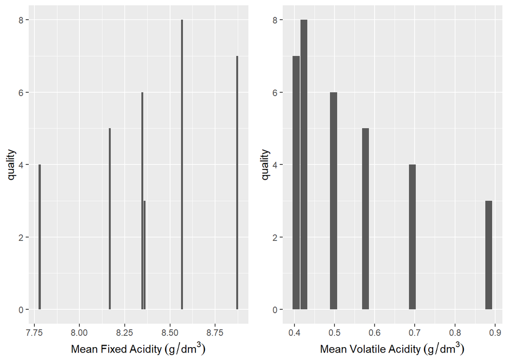

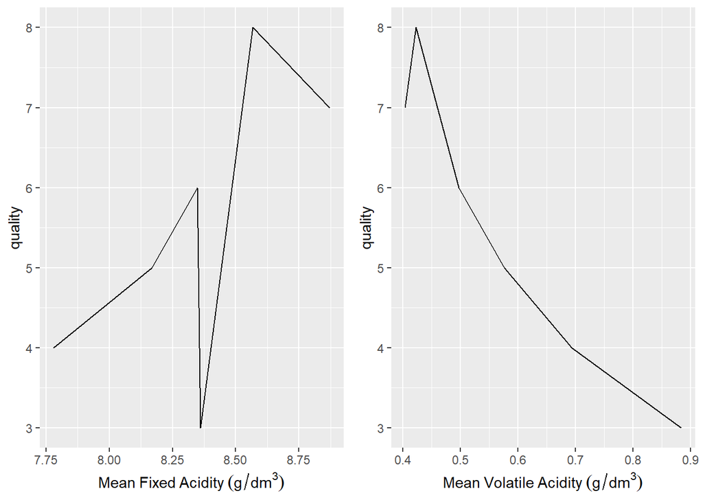

So I’ve run two plot types, histogram and line, of the means of fixed acidity and volatile acidity. They both tell the same story.

Looking at the scale of the mean fixed acidity, it is clear there is little difference in the means. Values only go from 7.75 to 8.8. Volatile acids in contrast go from 0.4 to 0.9, and it’s clear from this view that lower volatiles are correlated with higher quality wines. Again, given how little amounts of volatile acids are present in wine, it is unlikely that by themselves they have an impact on quality rating.

### Residual sugar and Quality

Recall our raw residual sugar data is highly skewed, with most values between 1 and 5. Nevertheless, let us see what raw data looks like in a box plot versus quality.

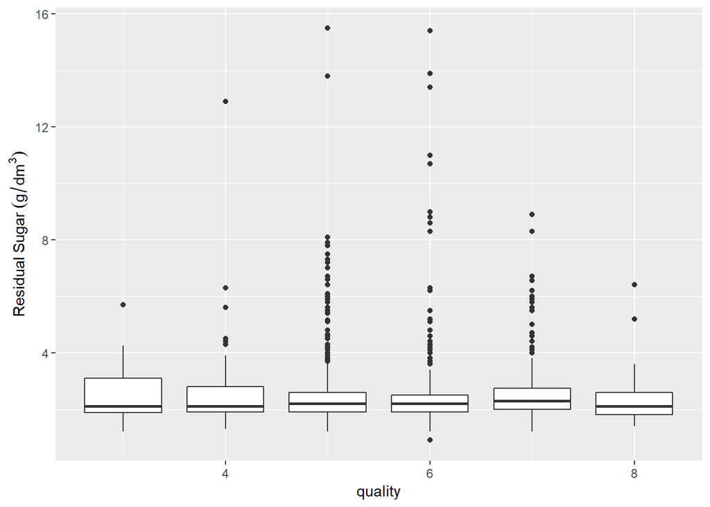

I will run three boxplots of same data: raw data, limited data range 1 to 5, and log transformed data, and see if any interesting insights are exposed.

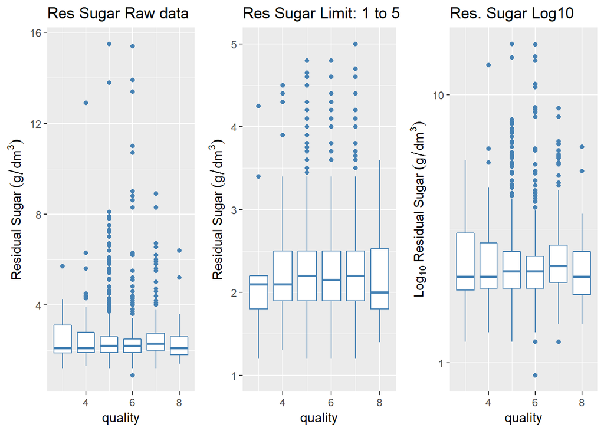

The skewedness of the data is certainly reduced by both the limit function and log-transformation. But we still observe significant outliers in these box plots. For reasons of completeness of data, I will continue to use the log-transformed values.

There does not appear to be significant difference in residual sugar across the different levels of quality, from these box plots.

Again, let us apply a correlation test to this.

```
##
##  Pearson's product-moment correlation
##
## data:  residual.sugar and quality
## t = 0.5488, df = 1597, p-value = 0.5832
## alternative hypothesis: true correlation is not equal to 0
## 95 percent confidence interval:
##  -0.03531327  0.06271056
## sample estimates:
##        cor
## 0.01373164
```

Just to be sure, let’s run the test again, this time limiting residual sugar to between 1 and 5 inclusive.

```
##
##  Pearson's product-moment correlation
##
## data:  residual.sugar and quality
## t = 0.4089, df = 1511, p-value = 0.6827
## alternative hypothesis: true correlation is not equal to 0
## 95 percent confidence interval:
##  -0.03989807  0.06088176
## sample estimates:
##        cor
## 0.01051856
```

Let’s run a third correlation test, this time using log-transformed residual sugar.

```
##
##  Pearson's product-moment correlation
##
## data:  log10(residual.sugar) and quality
## t = 0.94071, df = 1597, p-value = 0.347
## alternative hypothesis: true correlation is not equal to 0
## 95 percent confidence interval:
##  -0.02551727  0.07247084
## sample estimates:
##        cor
## 0.02353331
```

So far, we’ve looked at acidity and residual sugar, two of the most important characteristics of wine in terms of composition. And we’ve found no strong correlation to quality among these two.

There are two other attributes I want to look at, that seem to account for big chunks of wine composition: alcohol and sulfur dioxide. Let’s take the fun one first: alcohol.

### Alcohol and Quality

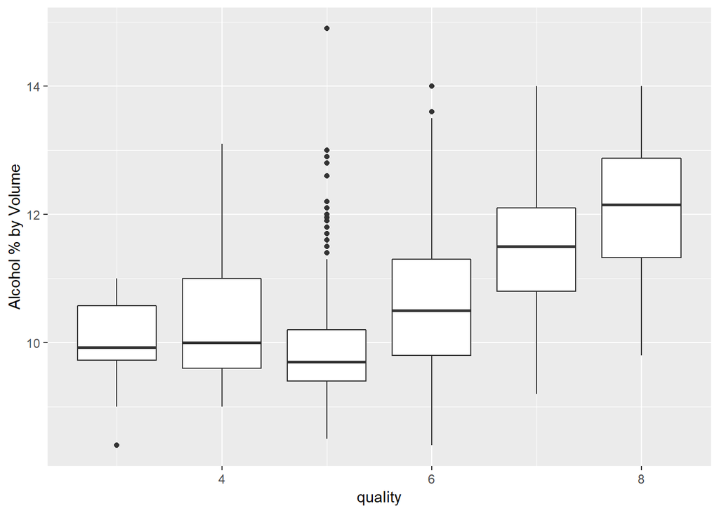

The boxplot shows quality rating increases with higher average alcohol content. This is an interesting and amusing finding!

Let’s run a correlation test to confirm this.

```
##
##  Pearson's product-moment correlation
##
## data:  alcohol and quality
## t = 21.639, df = 1597, p-value < 2.2e-16
## alternative hypothesis: true correlation is not equal to 0
## 95 percent confidence interval:
##  0.4373540 0.5132081
## sample estimates:
##       cor
## 0.4761663
```

Correlation coefficient is 0.47. While this does not reach the 0.7 mark to qualify as a strong correlation, it is a significant number. So we can say alcohol appears to have a moderate positive correlation with wine quality rating. My friends will tell me I did not need to run a correlation test to discover this!

### Sulfur dioxide and Quality

Running a box plot on the raw sulfur dioxide data, we obtain the graph below.

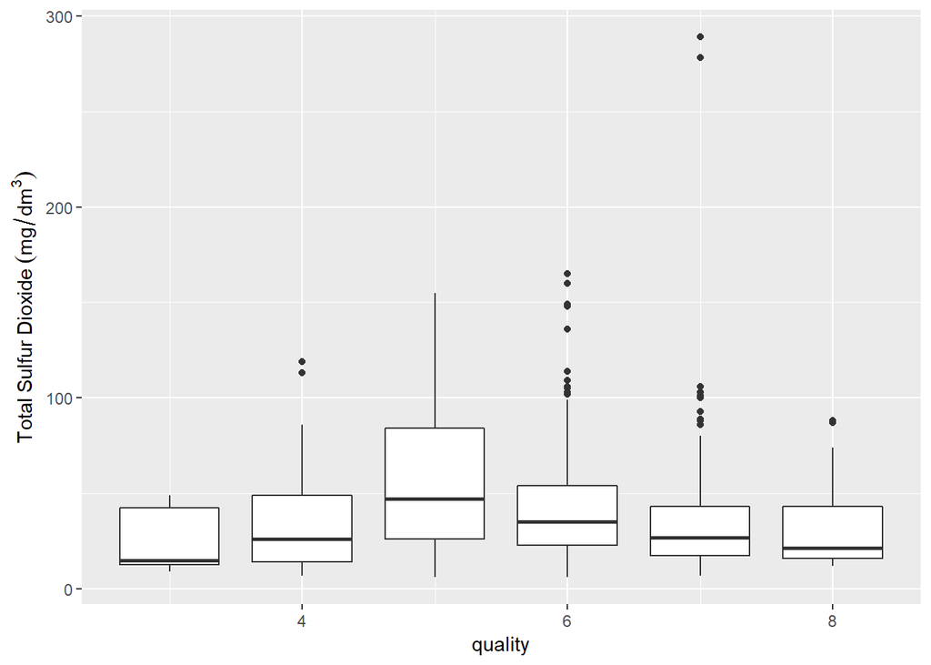

Total sulfur dioxide is highly skewed. Let’s apply a log transformation

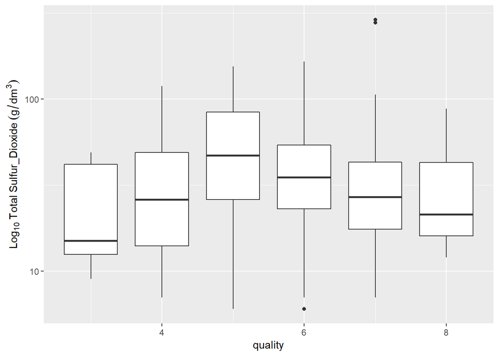

Applying log transform, we reduce the skewedness of the distribution. We can now see with greater confidence that total sulfur dioxide appears to have very little bearing on quality rating. We can see this in the boxplot, from the mean values across different quality ratings.

Let’s run a correlation test to confirm this.

```
##
##  Pearson's product-moment correlation
##
## data:  total.sulfur.dioxide and quality
## t = -7.5271, df = 1597, p-value = 8.622e-14
## alternative hypothesis: true correlation is not equal to 0
## 95 percent confidence interval:
##  -0.2320162 -0.1373252
## sample estimates:
##        cor
## -0.1851003
```

```
##
##  Pearson's product-moment correlation
##
## data:  log10(total.sulfur.dioxide) and quality
## t = -6.8999, df = 1597, p-value = 7.476e-12
## alternative hypothesis: true correlation is not equal to 0
## 95 percent confidence interval:
##  -0.2173510 -0.1221403
## sample estimates:
##        cor
## -0.1701427
```

We have performed two tests, one with the raw but skewed total sulfur dioxide values, and the second with log-transformed values. Both tell the same tale: very low negative correlation coefficient. My hunch appears to be incorrect.

### Alcohol and Sulfur Dioxide

But is alcohol content negatively correlated with sulfur dioxide? Remember that sulfur dioxide is added to wine to inhibit yeast action, that is, to stop fermentation.

Let’s do a scatter plot to find out.

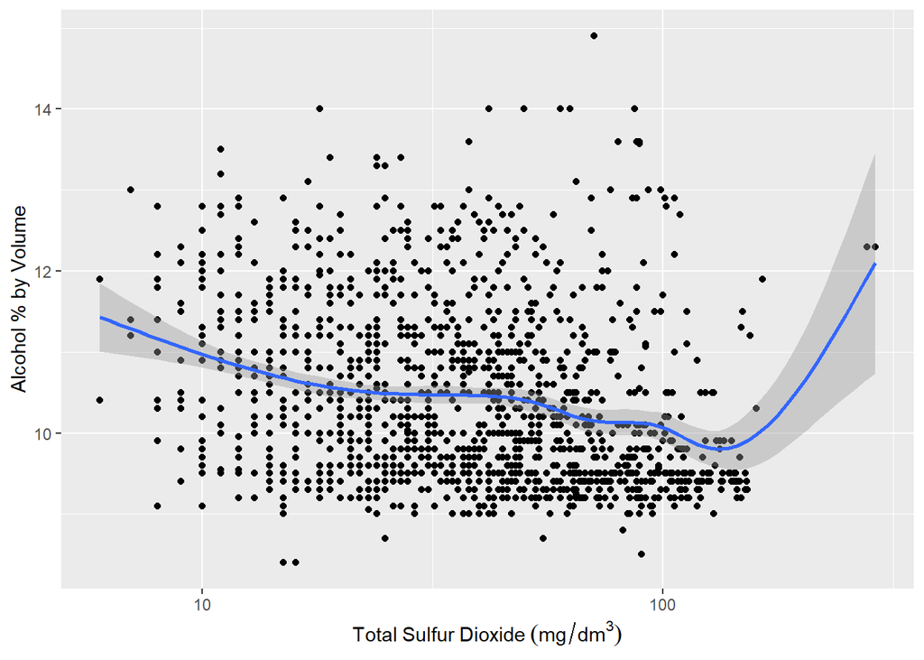

```
##
##  Pearson's product-moment correlation
##
## data:  log10(total.sulfur.dioxide) and alcohol
## t = -9.4818, df = 1597, p-value < 2.2e-16
## alternative hypothesis: true correlation is not equal to 0
## 95 percent confidence interval:
##  -0.2767472 -0.1839183
## sample estimates:
##       cor
## -0.230858
```

So from looking at both the scatter plot and the correlation coefficient, we can say there is a weak negative correlation between sulfur dioxide and alcohol content. So it is incorrect to assume higher levels of sulfur dioxide translate to lower levels of alcohol. Curious result, but quite instructive nonetheless.

### Sulphates and Quality

Let us now see how sulphates are distributed across quality levels, in a box plot. Our univariate exploration showed how skewed the rar data is, so we will use the log transformed data directly.

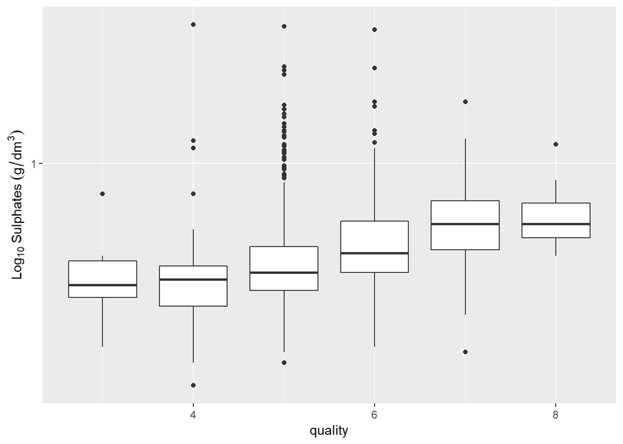

From the box plot, it appears that wines with higher amount of sulphates tend to have higher quality. We get this view visually by looking at the means. But is this really what the data suggests?

Let’s use a scatter plot and a correlation test.

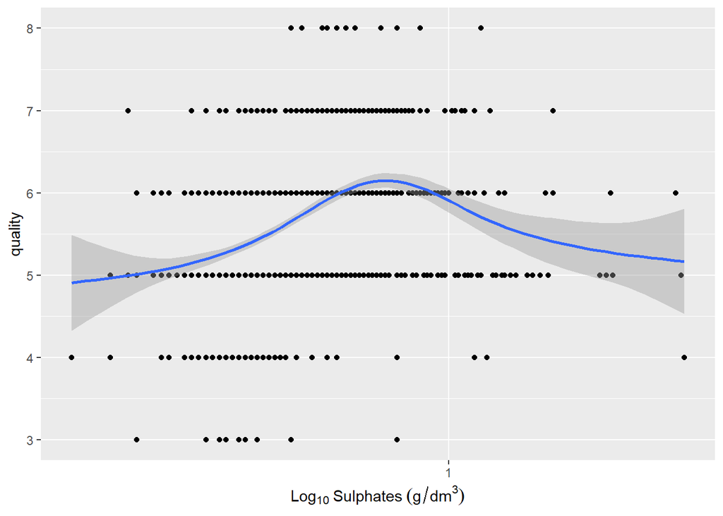

```
##
##  Pearson's product-moment correlation
##
## data:  sulphates and quality
## t = 10.38, df = 1597, p-value < 2.2e-16
## alternative hypothesis: true correlation is not equal to 0
## 95 percent confidence interval:
##  0.2049011 0.2967610
## sample estimates:
##       cor
## 0.2513971
```

Scatter plot and correlation test indicate there is only a weak relationship between amount of sulphates in wine and quality rating.

### Citric Acid and Quality

Do we observe a correlation between citric acid and quality? We will use a scatter plot, box plot and correlation test to investigate

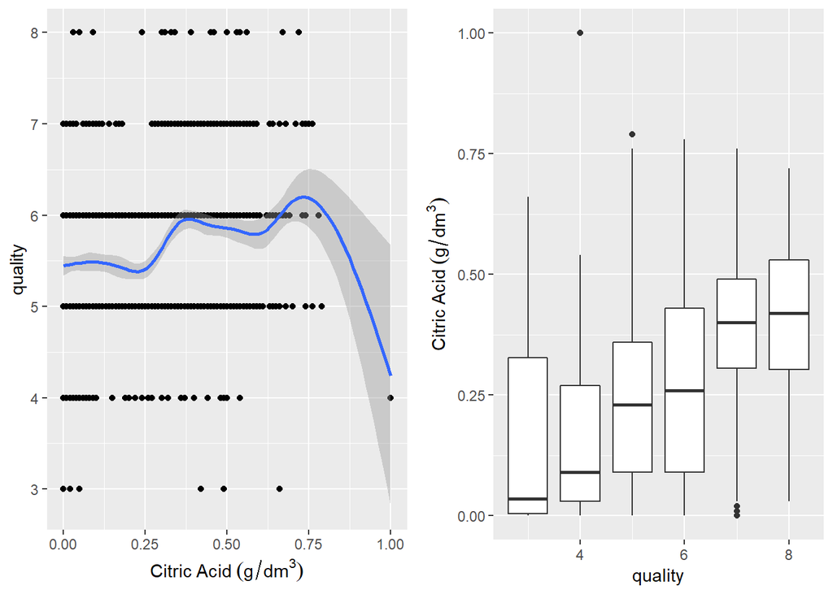

```
##
##  Pearson's product-moment correlation
##
## data:  citric.acid and quality
## t = 9.2875, df = 1597, p-value < 2.2e-16
## alternative hypothesis: true correlation is not equal to 0
## 95 percent confidence interval:
##  0.1793415 0.2723711
## sample estimates:
##       cor
## 0.2263725
```

Citric acid appears to have a weak correlation to quality, but at 0.22 this is too weak to draw a reliable conclusion. The box plot helps us infer that this correlation may be influenced by outliers at quality levels 4 and 7.

### Density and Quality

How does density differ by quality rating? Let’s use a facet wrap on density histogram to find out

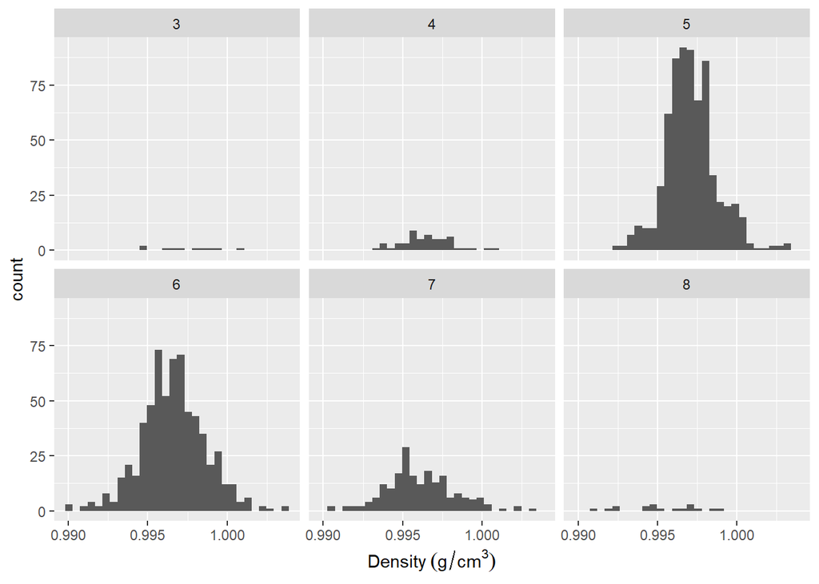

It’s apparent that a normal distribution of density is present across all quality ratings. Let us use a box plot to see if quality related differences can be exposed.

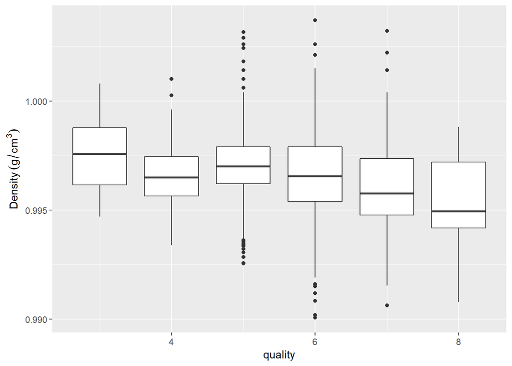

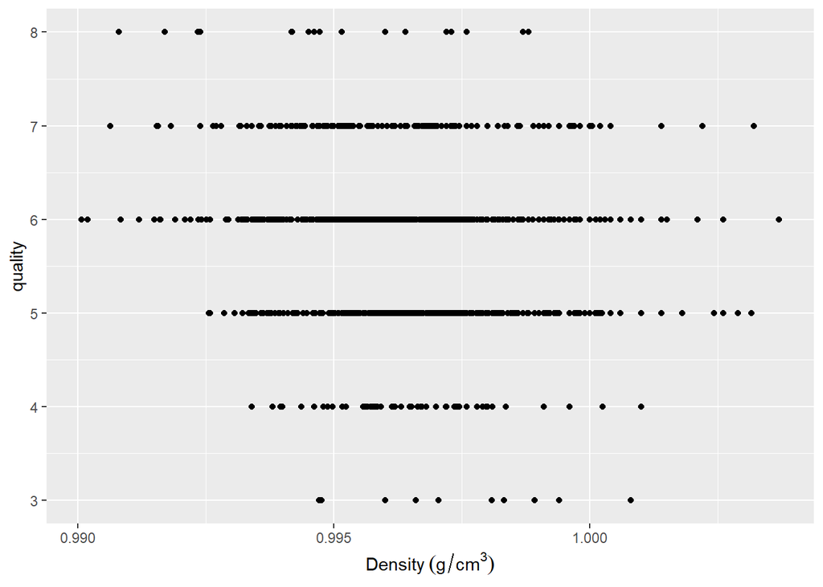

Here we compare quality to density. There appears to be a very weak negative correlation of density to quality. Let’s calculate the correlation coefficient between density and quality.

```
##
##  Pearson's product-moment correlation
##
## data:  density and quality
## t = -7.0997, df = 1597, p-value = 1.875e-12
## alternative hypothesis: true correlation is not equal to 0
## 95 percent confidence interval:
##  -0.2220365 -0.1269870
## sample estimates:
##        cor
## -0.1749192
```

As suspected, a weak negative correlation exists between density and quality. Still, quite surprising. I would have expected higher density wines to be rated higher.

### Density and Alcohol

I’ll test to confirm the correlation between density and alcohol content.

First, a scatter plot, and then a correlation test.

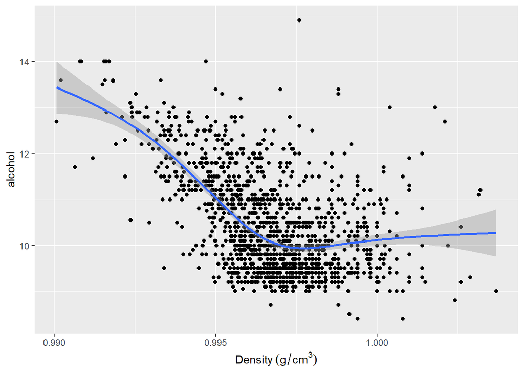

```
##
##  Pearson's product-moment correlation
##
## data:  density and alcohol
## t = -22.838, df = 1597, p-value < 2.2e-16
## alternative hypothesis: true correlation is not equal to 0
## 95 percent confidence interval:
##  -0.5322547 -0.4583061
## sample estimates:
##        cor
## -0.4961798
```

## Bivariate Analysis

### Relationship Insights

I was quite surprised to find acidity and residual sugars had no correlation to quality. Volatile acidity did have a moderate negative correlation; but volatile acidity accounts for a tiny proportion of wine content, so I’m taking the view this is a co-incidence. In fact, most of the attributes examined had no demonstrable relationship to quality.

On the other hand, alcohol did show a moderate correlation to quality. This was not surprising, but nontheless interesting to verify with data.

## Multivariate Plots Section

### Wine Chemical Composition

Let us assume that the compounds in our dataset comprehensively describe the composition of wine. It would be nice to see how each component of wine adds up to a total composition. This can help us understand what the main components of wine are, and identify those attributes that occur only in very tiny amounts.

Most of our columns are values given in ‘g / dm^3’, grams per cubic decimeter.

We will add a new column, adding up the relevant components per observation. Obviously, attributes like pH and density are not components and will not be summed. Further, free sulfur dioxide and total sulfur dioxide are in milligrams, so need to be converted to grams. And ‘sulphates’ in the dataset refers to potassium sulphate. This compound is added to wine and some of it gets converted to sulphur dioxide gas. Given our dataset also lists sulfur dioxide, I will add both values to derive a complete view of sulphates present in wine.

Details of the columns in the dataset are provided here: https://s3.amazonaws.com/udacity-hosted-downloads/ud651/wineQualityInfo.txt

```
## 'data.frame':    1599 obs. of  14 variables:
##  $ X                   : int  1 2 3 4 5 6 7 8 9 10 ...
##  $ fixed.acidity       : num  7.4 7.8 7.8 11.2 7.4 7.4 7.9 7.3 7.8 7.5 ...
##  $ volatile.acidity    : num  0.7 0.88 0.76 0.28 0.7 0.66 0.6 0.65 0.58 0.5 ...
##  $ citric.acid         : num  0 0 0.04 0.56 0 0 0.06 0 0.02 0.36 ...
##  $ residual.sugar      : num  1.9 2.6 2.3 1.9 1.9 1.8 1.6 1.2 2 6.1 ...
##  $ chlorides           : num  0.076 0.098 0.092 0.075 0.076 0.075 0.069 0.065 0.073 0.071 ...
##  $ free.sulfur.dioxide : num  11 25 15 17 11 13 15 15 9 17 ...
##  $ total.sulfur.dioxide: num  34 67 54 60 34 40 59 21 18 102 ...
##  $ density             : num  0.998 0.997 0.997 0.998 0.998 ...
##  $ pH                  : num  3.51 3.2 3.26 3.16 3.51 3.51 3.3 3.39 3.36 3.35 ...
##  $ sulphates           : num  0.56 0.68 0.65 0.58 0.56 0.56 0.46 0.47 0.57 0.8 ...
##  $ alcohol             : num  9.4 9.8 9.8 9.8 9.4 9.4 9.4 10 9.5 10.5 ...
##  $ quality             : int  5 5 5 6 5 5 5 7 7 5 ...
##  $ total_compo         : num  10.7 12.1 11.7 14.7 10.7 ...
```

```
##    Min. 1st Qu.  Median    Mean 3rd Qu.    Max.
##   7.588  10.722  11.887  12.449  13.720  27.589
```

Having added this composition column, let us see what its values look like in relation to density. My reasoning is the higher the total composition value, the greater density the wine is likely to possess. So we should see a strong correlation between total composition and density.

```
##
##  Pearson's product-moment correlation
##
## data:  total_compo and density
## t = 40.812, df = 1597, p-value < 2.2e-16
## alternative hypothesis: true correlation is not equal to 0
## 95 percent confidence interval:
##  0.6896341 0.7376837
## sample estimates:
##       cor
## 0.7145003
```

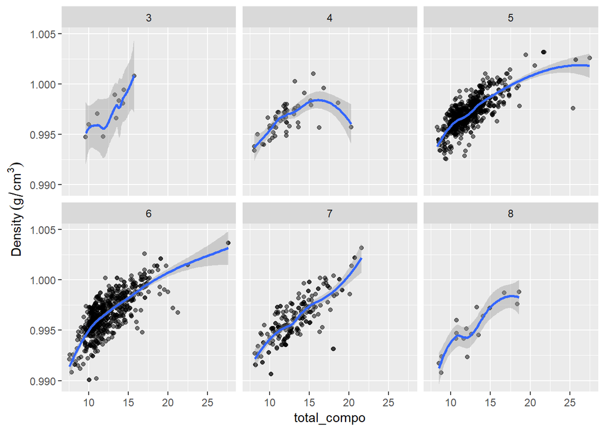

Given the high correlation coefficient (0.71) and the view from the scatter plots above faceted by quality, we are satisfied that our total composition number is sound. It is clear to see from the scatter plots that total composition values correlate positively with density.

The obvious next question is in terms of actual composition: which compounds account for the largest proportions?

One way to answer this question is to create a pie chart of the average the components we’ve summed, as a proportion of total composition.

We’ll use a new dataframe to do this. First step will be to copy our wines dataframe and then calculate porportion values in separate columns.

```
## logical(0)
```

```
## 'data.frame':    1599 obs. of  6 variables:
##  $ X            : int  1 2 3 4 5 6 7 8 9 10 ...
##  $ fix_acid     : num  0.694 0.643 0.667 0.764 0.694 ...
##  $ cit_acid     : num  0 0 0.00342 0.03821 0 ...
##  $ res_sugar    : num  0.178 0.214 0.197 0.13 0.178 ...
##  $ chl          : num  0.00712 0.00808 0.00787 0.00512 0.00712 ...
##  $ sulphates_all: num  0.0557 0.0616 0.0602 0.0437 0.0557 ...
```

```
## [1] "X"             "fix_acid"      "cit_acid"      "res_sugar"
## [5] "chl"           "sulphates_all"
```

I have created a new dataframe holding the proportion values for each observation, and deleted unneeded columns.

I will now create a new dataframe that holds the proportion means of each data attribute or column.

```
##               rn t.data.frame.wine_prop_means..
## 1:      fix_acid                     0.67017758
## 2:      cit_acid                     0.02070916
## 3:     res_sugar                     0.19967884
## 4:           chl                     0.00714516
## 5: sulphates_all                     0.05799523
```

```
##             item     values
## 1:      fix_acid 0.67017758
## 2:      cit_acid 0.02070916
## 3:     res_sugar 0.19967884
## 4:           chl 0.00714516
## 5: sulphates_all 0.05799523
```

Dataframe with proportion means per attribute is now created. Above are the average compositional proportions of wines in our dataset.

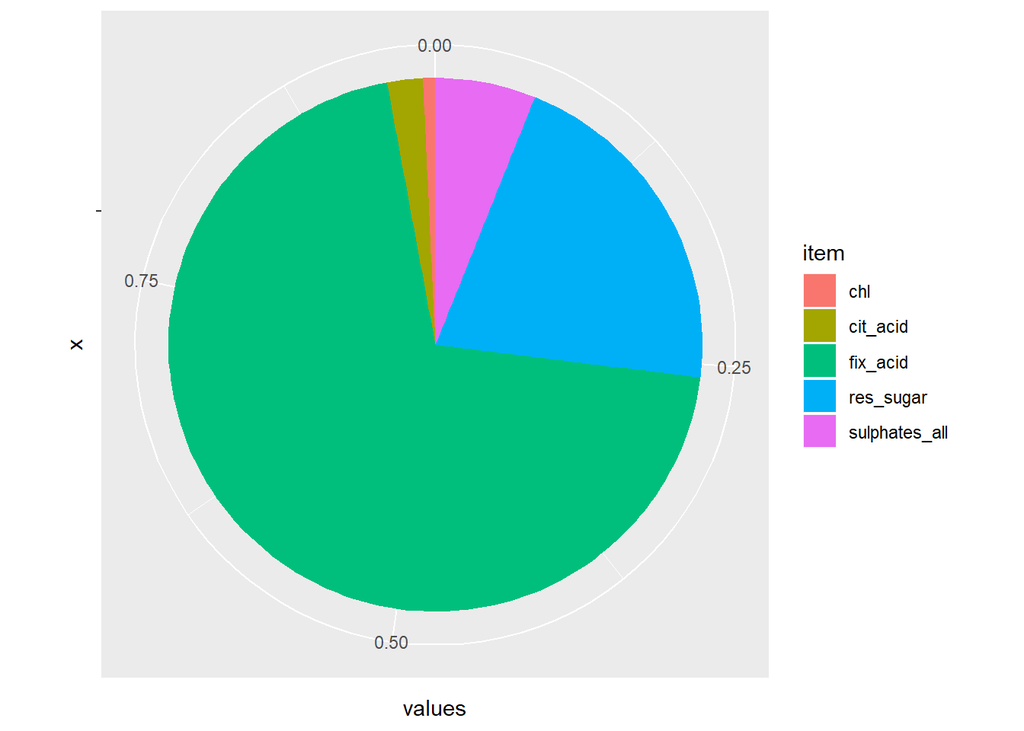

It is clear from this pie chart that fixed acidity, residual sugar, sulphates and citric acid account for the bulk (94%) of the average chemical composition of wine.